# Assignment_4(Ensemble_Learning)

### Import Libraries

```python
import numpy as np
from sklearn.base import clone
import matplotlib.pyplot as plt
from matplotlib.colors import ListedColormap
from sklearn.datasets import make_circles
from sklearn.datasets import make_classification
from sklearn.model_selection import train_test_split
from sklearn.tree import DecisionTreeClassifier
from sklearn.metrics import accuracy_score
from sklearn.model_selection import cross_val_score
from sklearn.ensemble import BaggingClassifier
from sklearn.ensemble import RandomForestClassifier
from sklearn.ensemble import AdaBoostClassifier
from sklearn.linear_model import LogisticRegression
from sklearn.naive_bayes import GaussianNB
from sklearn.ensemble import StackingClassifier
```

```python
def plotDataset(X, y):
  for label in np.unique(y):
    plt.scatter(X[y == label, 0], X[y == label, 1], label=label)
    plt.legend()
    plt.show()


def plotEstimator(trX, trY, teX, teY, estimator, title=''):
  estimator = clone(estimator).fit(trX, trY)
  h = .02
  x_min, x_max = teX[:, 0].min() - .5, teX[:, 0].max() + .5
  y_min, y_max = teX[:, 1].min() - .5, teX[:, 1].max() + .5
  xx, yy = np.meshgrid(np.arange(x_min, x_max, h), np.arange(y_min, y_max, h))
  cm = plt.cm.RdBu
  cm_bright = ListedColormap(['#FF0000', '#0000FF'])
  Z = estimator.predict_proba(np.c_[xx.ravel(), yy.ravel()])[:, 1]
  Z = Z.reshape(xx.shape)
  plt.contourf(xx, yy, Z, cmap=cm, alpha=0.8)
  plt.scatter(teX[:, 0], teX[:, 1], c=teY, cmap=cm_bright, edgecolors='k', alpha=0.6)
  #plt.legend()
  plt.title(title)
  plt.show()
```

### Data Sets

#### Circle dataset

```python
rs = 0
X, y = make_circles(300, noise=0.1, random_state=rs)
X_train, X_test, y_train, y_test = train_test_split(X, y, test_size=0.2,random_state=rs)
```

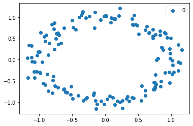

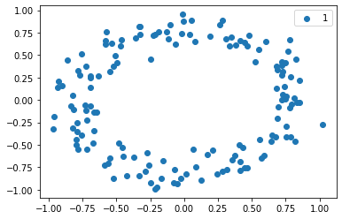

```python
plotDataset(X,y)
```

#### Classification dataset

```python
rs = 0
X2, y2 = make_classification(300, random_state=rs)
X_train2, X_test2, y_train2, y_test2 = train_test_split(X2, y2, test_size=0.2,random_state=rs)
```

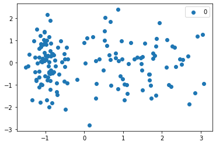

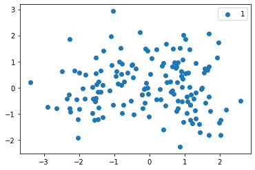

```python
plotDataset(X2,y2)
```

### Decision Tree

#### **(4)** Use Circle Dataset. Apply decision tree on the Circle Dataset, set criterion as gini and entropy, get the accuracy of the testing results, plot the decision boundaries and explain the difference between these criterion

##### (4.1) DT with gini Index

```
test accuracy is:  0.6
```

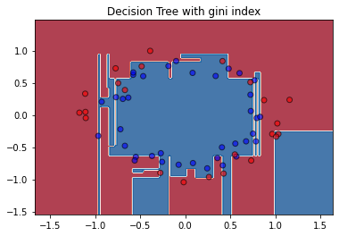

```python
dtEstimator_gini = DecisionTreeClassifier(criterion="gini")
dtEstimator_gini.fit(X_train, y_train)
predY = dtEstimator_gini.predict(X_test)
dtAccuracy = accuracy_score(y_test, predY)
print("test accuracy is: ",round(dtAccuracy,3))
plotEstimator(X_train, y_train, X_test, y_test, dtEstimator_gini, 'Decision Tree with gini index')
```

##### (4.2) DT with entropy

```
test accuracy is:  0.717
```

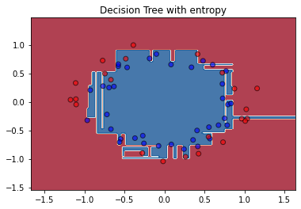

```python
dtEstimator_entropy = DecisionTreeClassifier(criterion="entropy")
dtEstimator_entropy.fit(X_train, y_train)
predY = dtEstimator_entropy.predict(X_test)
dtAccuracy = accuracy_score(y_test, predY)
print("test accuracy is: ",round(dtAccuracy,3))
plotEstimator(X_train, y_train, X_test, y_test, dtEstimator_entropy, 'Decision Tree with entropy')
```

Gini measurement is the probability of a random sample being classified incorrectly if we randomly pick a label according to the distribution in a branch.

Entropy is a measurement of information (or rather lack thereof). You calculate the information gain by making a split. Which is the difference in entripies. This measures how you reduce the uncertainty about the label.

#### **(5)** Use Classification Dataset. Use training set to obtain the importance of features. Plot Validation Accuracy (y-axis) vs Top K Important Feature (x-axis) curve; where 4-fold cross validation should be used, and also plot Test Accuracy vs Top K Important Feature curve

```python
def plot_importance_vs_accuracys(values, axis_values, title):

    plt.figure(figsize=(8,5))

    if len(axis_values) == 4:

        axis_1 = plt.plot(values, axis_values[0], color='red', marker='*',
                         linestyle='-', label = '1st fold')
        axis_2 = plt.plot(values, axis_values[1], color='green', marker='*',
                         linestyle='-', label = '2nd fold')
        axis_3 = plt.plot(values, axis_values[2], color='blue', marker='*',
                         linestyle='-', label = '3rd fold')
        axis_4 = plt.plot(values, axis_values[3], color='yellow', marker='*',
                         linestyle='-', label = '4th fold')

        plt.title(title)
        plt.xlabel('Top K Important Features')
        plt.ylabel('Validation Accuracy')
        plt.xticks([x for x in range(len(values))])
        y_ticks = [x for x in range(60,101,5)]
        plt.yticks(y_ticks)
        plt.legend(bbox_to_anchor=(1.05, 1), loc=2, borderaxespad=0.)

    else:
        axis1 = plt.plot(values, axis_values, color='blue', marker='*',
                         linestyle='-')

        plt.title(title)
        plt.xlabel('Top K Important Features')
        plt.ylabel('Test Accuracy')
        plt.xticks([x for x in range(len(values))])
        y_ticks = [x for x in range(80,101,2)]
        plt.yticks(y_ticks)

    plt.show
```

##### **(5.1)** get top K important features

```python
tree_model = DecisionTreeClassifier(random_state=0)
tree_model.fit(X_train2, y_train2)
features_import = tree_model.feature_importances_
idx_sorted = np.argsort(-features_import)[0:7]
idx_sorted
```

```
array([ 8,  0, 18, 10, 17, 14, 11])
```

##### **(5.2)** fit DT model with top K features using 4-folds cross validation

```python
test_accuracy = []
validation_accuracy = []
l1 = idx_sorted[0:1]
l2 = idx_sorted[0:2]
l3 = idx_sorted[0:3]
l4 = idx_sorted[0:4]
l5 = idx_sorted[0:5]
l6 = idx_sorted[0:6]
l7 = idx_sorted[0:7]
feature_list = [l1,l2,l3,l4,l5,l6,l7]
for features in feature_list:
  valid_acc = cross_val_score(tree_model, X_train2[:,features], y_train2, cv=4, scoring='accuracy')
  validation_accuracy.append(valid_acc * 100)
  tree_model.fit(X_train2[:,features], y_train2)
  y_pred = tree_model.predict(X_test2[:, features])
  test_acc =  accuracy_score(y_test2, y_pred)
  test_accuracy.append(test_acc * 100)

valid_acc = list(map(list, zip(*validation_accuracy)))
```

##### **(5.3)** Plot Validation Accuracy (y-axis) vs Top K Important Feature (x-axis) curve with 4-folds

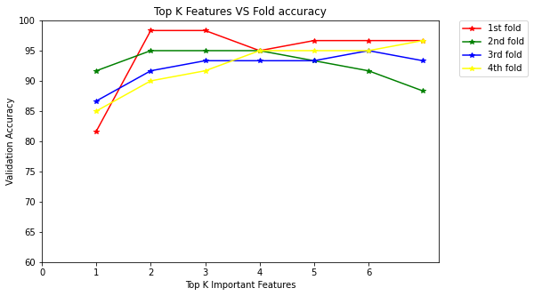

```python
values = [x for x in range(1,8)]
plot_importance_vs_accuracys(values[:8], valid_acc, "Top K Features VS Fold accuracy")
```

##### **(5.4)** plot Test Accuracy vs Top K Important Feature curve

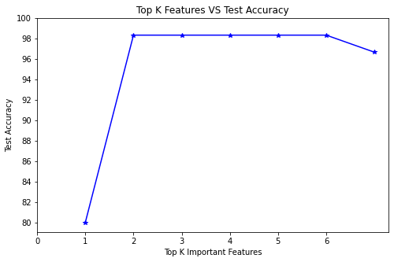

```python
values = [x for x in range(1,8)]
plot_importance_vs_accuracys(values[:8], test_accuracy, "Top K Features VS Test Accuracy");
```

### Bagging

#### **(6)** Use Circle Dataset. Set the number of estimators as 2, 5, 15, 20 respectively, and generate the results accordingly (i.e., accuracy and decision boundary)

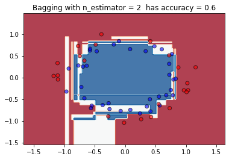

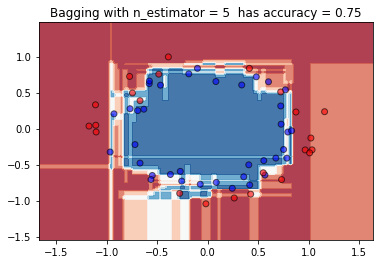

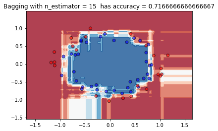

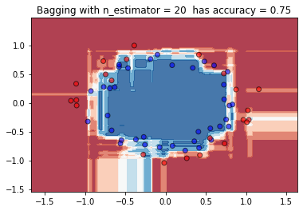

```python
for n_est in [2,5,15,20]:
  estimator = BaggingClassifier(n_estimators=n_est, random_state=0)
  score = estimator.fit(X_train, y_train).score(X_test, y_test)
  plotEstimator(X_train, y_train, X_test, y_test, estimator, f'Bagging with n_estimator = {n_est}  has accuracy = {score}')
```

#### **(7)** Explain why bagging can reduce the variance and mitigate the overfitting problem

Bagging can create many predictors by bootstrapping the data randomly subsample the dataset many times, and train a model using each subsample. We can then aggregate our models, e.g., averaging out the predictions of each model. and this can reduce variance and overfitting

### Random Forest

#### **(8)** Use Circle Dataset. Set the number of estimators as 2, 5, 15, 20 respectively, and generate the results accordingly (i.e., accuracy and decision boundary)

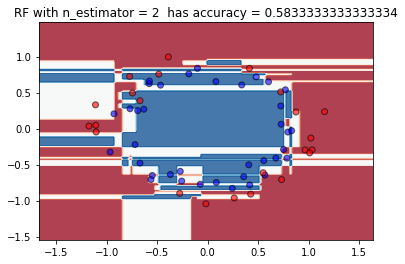

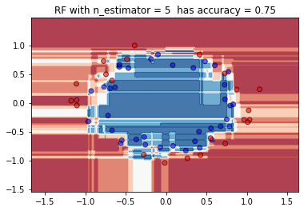

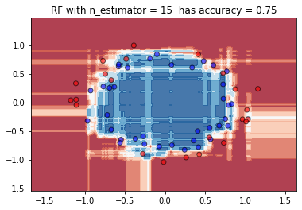

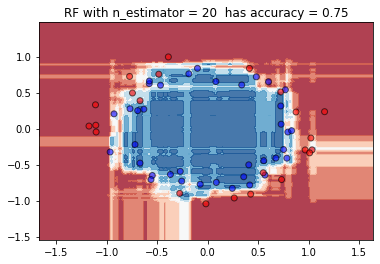

```python
for n_est in [2,5,15,20]:
  estimator =  RandomForestClassifier(n_estimators=n_est, random_state=0)
  score = estimator.fit(X_train, y_train).score(X_test, y_test)
  plotEstimator(X_train, y_train, X_test, y_test, estimator, f'RF with n_estimator = {n_est}  has accuracy = {score}')
```

#### **(9)** Compare with bagging results and explain the difference between Bagging and Random Forest

The fundamental difference is that in Random forests, only a subset of features are selected at random out of the total and the best split feature from the subset is used to split each node in a tree, unlike in bagging where all features are considered for splitting a node.

### Boosting

#### **(10)** Use Circle Dataset. There are 2 important hyperparameters in AdaBoost, i.e., the number of estimators (ne), and learning rate (lr). Please plot 12 subfigures as the following table's setup. Each figure should plot the decision boundary and each of their title should be the same format as {n_estimaotrs}, {learning_rate}, {accuracy}

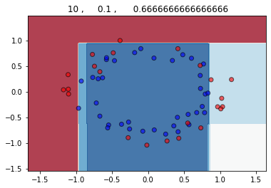

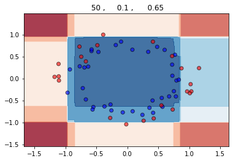

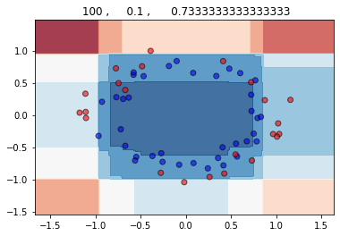

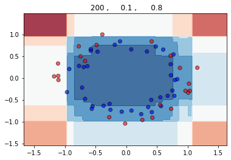

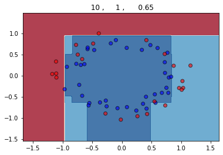

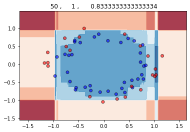

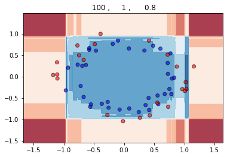

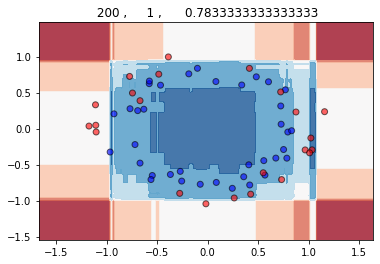

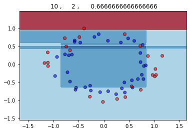

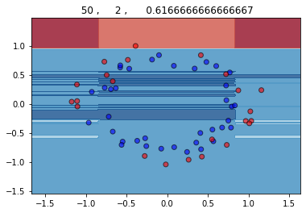

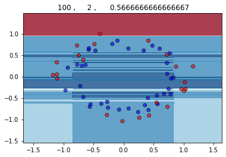

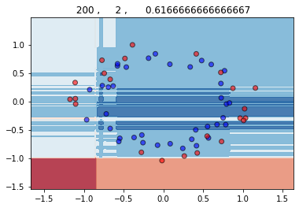

```python
n_estimator = [10,50,100,200]
l_rate = [0.1,1,2]
for l in l_rate:
  for n_est in n_estimator:
    estimator =  AdaBoostClassifier(n_estimators= n_est, learning_rate= l)
    score = estimator.fit(X_train, y_train).score(X_test, y_test)
    plotEstimator(X_train, y_train, X_test, y_test, estimator, f' {n_est} ,     {l} ,      {score}')
```

### Stacking

#### **(11)** We have tuned the Decision Tree, Bagging, Random Forest, and AdaBoost in the previous section. Use these fine tuned model as base estimators and use Naive Bayes, Logistic Regression, and Decision Tree as aggregators to generate the results accordingly (i.e., accuracy and decision boundary)

##### Base Estimaters

```python
base_estimaters = list()
base_estimaters.append(('DT',DecisionTreeClassifier(criterion="entropy", random_state=0)))
base_estimaters.append(('Bagging' ,BaggingClassifier(n_estimators=5, random_state=0)))
base_estimaters.append(('RF', RandomForestClassifier(n_estimators=5, random_state=0)))
base_estimaters.append(('Adaboost', AdaBoostClassifier(n_estimators=50, learning_rate= 1, random_state=0)))
```

#### (11.1) Naive Bayes as Aggregator

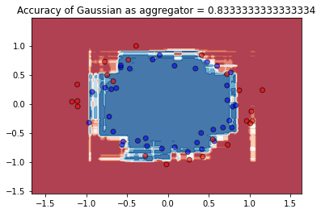

```python
aggregator1 =GaussianNB()
model1 = StackingClassifier(estimators=base_estimaters, final_estimator=aggregator1, cv=5)
score = model1.fit(X_train, y_train).score(X_test, y_test)
plotEstimator(X_train, y_train, X_test, y_test, model1, f'Accuracy of Gaussian as aggregator = {score}')
```

#### (11.2) Logistic Regression as Aggregator

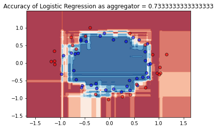

```python
aggregator2 =LogisticRegression()
model2 = StackingClassifier(estimators=base_estimaters, final_estimator=aggregator2, cv=5)
score = model2.fit(X_train, y_train).score(X_test, y_test)
plotEstimator(X_train, y_train, X_test, y_test, model2, f'Accuracy of Logistic Regression as aggregator = {score}')
```

#### (11.3) Decision Tree as Aggregator

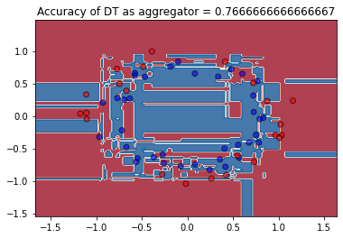

```python
aggregator3 =DecisionTreeClassifier()
model3 = StackingClassifier(estimators=base_estimaters, final_estimator=aggregator3, cv=5)
score = model3.fit(X_train, y_train).score(X_test, y_test)
plotEstimator(X_train, y_train, X_test, y_test, model3, f'Accuracy of DT as aggregator = {score}')
```